# Decision Trees

Kim Pham

11/14/2017

## 0. Load libraries

```r
library(ggplot2)
library(rpart)
library(ROCR)
library(dplyr)
library(psych)
library(caret)
```

## 1. Upload data file

Data file description: The data comes from an one level of an online geography tutoring system used by 5th grade students. The game involves: - a pre-test of geography knowledge (pre.test), - a series of assignments for which you have the average score (av.assignment.score), - the number of messages sent by each student to other students about the assignments (messages), - the number of forum posts students posted asking questions about the assignment (forum.posts), - a post test at the end of the level (post.test) - and whether or not the system allowed the students to go on to the next level (level.up).

```r
df <- read.csv("Data/online.data.csv")
```

## 2. Visualize data

#### Comparison between pre-test and post-test scores and those did or did not level up.

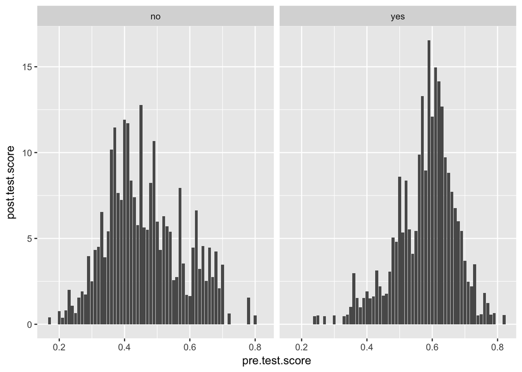

```r
h <- ggplot(data = df, aes(x = pre.test.score, y = post.test.score)) + geom_histogram(stat="identity")
h + facet_wrap(~level.up)
```

From the visualization, we can see that those who leveled up had higher pre.test.scores than those who did not.

#### Comparison between messages, forum.posts, and av.assignment.score between all members of the course.

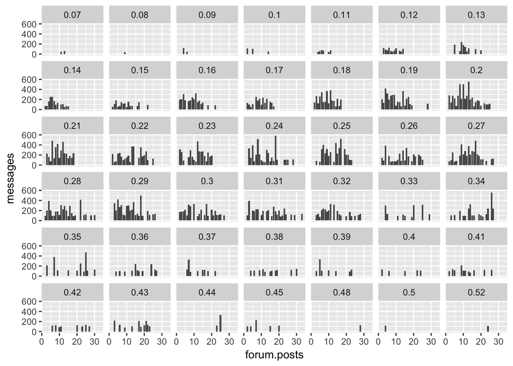

```r
h <- ggplot(data = df, aes(x = forum.posts, y = messages)) + geom_histogram(stat="identity")
h + facet_wrap(~av.assignment.score)
```

The visualization shows: * the individuals who scored the best in av.assignment.scores are on the higher end of forum.posts usage and on the lower end of messages usage. * the individuals who scored the least in av.assignment.scores are on the lower end of forum.posts usage and on the lower end of messages usage.

#### Comparison between messages, forum.posts, and av.assignment.score between members who leveled up.

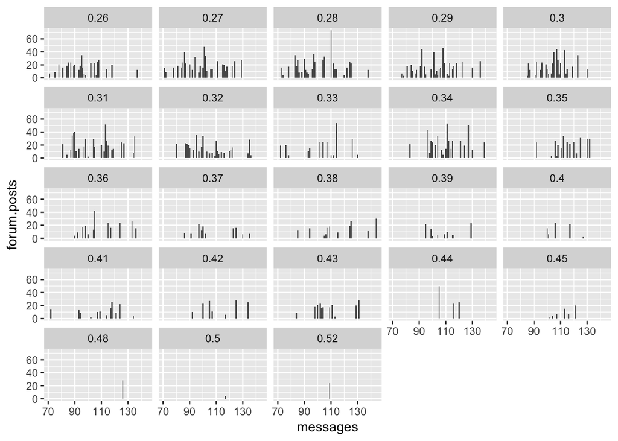

```r
h <- ggplot(data = filter(df, level.up=="yes"), aes(x = messages, y = forum.posts)) + geom_histogram(stat="identity")
h + facet_wrap(~av.assignment.score)
```

The visualization shows those who leveled up with the highest av.assignment.score are in the mid-range of messages usage and mid-range of forum posts usage.

#### Comparison between messages, forum.posts, and av.assignment.score between members who did not level up.

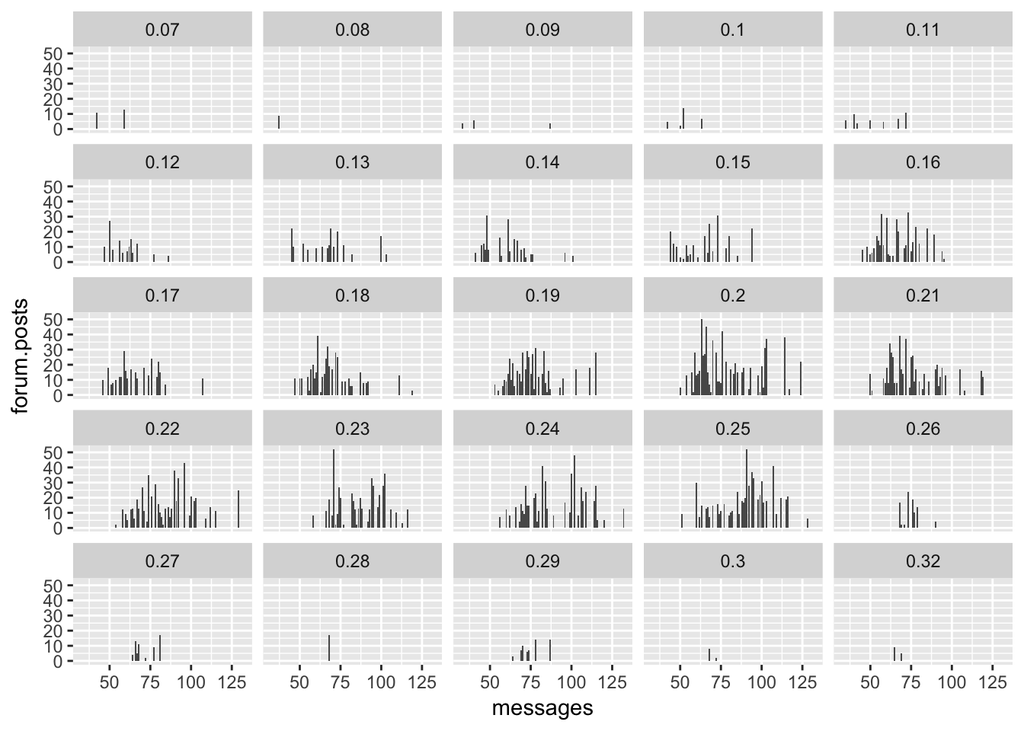

```r
h <- ggplot(data = filter(df, level.up=="no"), aes(x = messages, y = forum.posts)) + geom_histogram(stat="identity")
h + facet_wrap(~av.assignment.score)
```

The visualization shows those who did not level up with the highest av.assignment.score are in the lower-range of messages usage and mid-range of low range of forum posts usage.

## 3. Build classification tree

```r
c.tree <- rpart(level.up ~ messages + forum.posts + av.assignment.score, method="class", data=df, control=rpart.control(minsplit=15, cp=.00001))
printcp(c.tree)
```

```
##
## Classification tree:
## rpart(formula = level.up ~ messages + forum.posts + av.assignment.score,
##     data = df, method = "class", control = rpart.control(minsplit = 15,
##         cp = 1e-05))
##
## Variables actually used in tree construction:
## [1] av.assignment.score forum.posts         messages
##
## Root node error: 400/1000 = 0.4
##
## n= 1000
##
##        CP nsplit rel error xerror     xstd
## 1 0.93000      0    1.0000 1.0000 0.038730
## 2 0.03250      1    0.0700 0.0700 0.013042
## 3 0.00375      2    0.0375 0.0500 0.011068
## 4 0.00001      5    0.0250 0.0475 0.010793
```

```r
post(c.tree, file = "tree.ps", title = "Classification Tree")
c.tree
```

```
## n= 1000
##
## node), split, n, loss, yval, (yprob)
##       * denotes terminal node
##
##  1) root 1000 400 no (0.60000000 0.40000000)
##    2) av.assignment.score< 0.255 572   0 no (1.00000000 0.00000000) *
##    3) av.assignment.score>=0.255 428  28 yes (0.06542056 0.93457944)
##      6) messages< 77.5 33  10 no (0.69696970 0.30303030)
##       12) messages< 70.5 13   0 no (1.00000000 0.00000000) *
##       13) messages>=70.5 20  10 no (0.50000000 0.50000000)
##         26) forum.posts< 6.5 5   1 no (0.80000000 0.20000000) *
##         27) forum.posts>=6.5 15   6 yes (0.40000000 0.60000000)
##           54) messages>=72.5 10   4 no (0.60000000 0.40000000) *
##           55) messages< 72.5 5   0 yes (0.00000000 1.00000000) *
##      7) messages>=77.5 395   5 yes (0.01265823 0.98734177) *
```

## 4. Predict probability a student levels up

```r
df$pred <- predict(c.tree, df, type = "prob")[,2] # type = "prob" to see the probability that our classififcation is based on.
```

## 5. Evaluate model predictions (ROC curve)

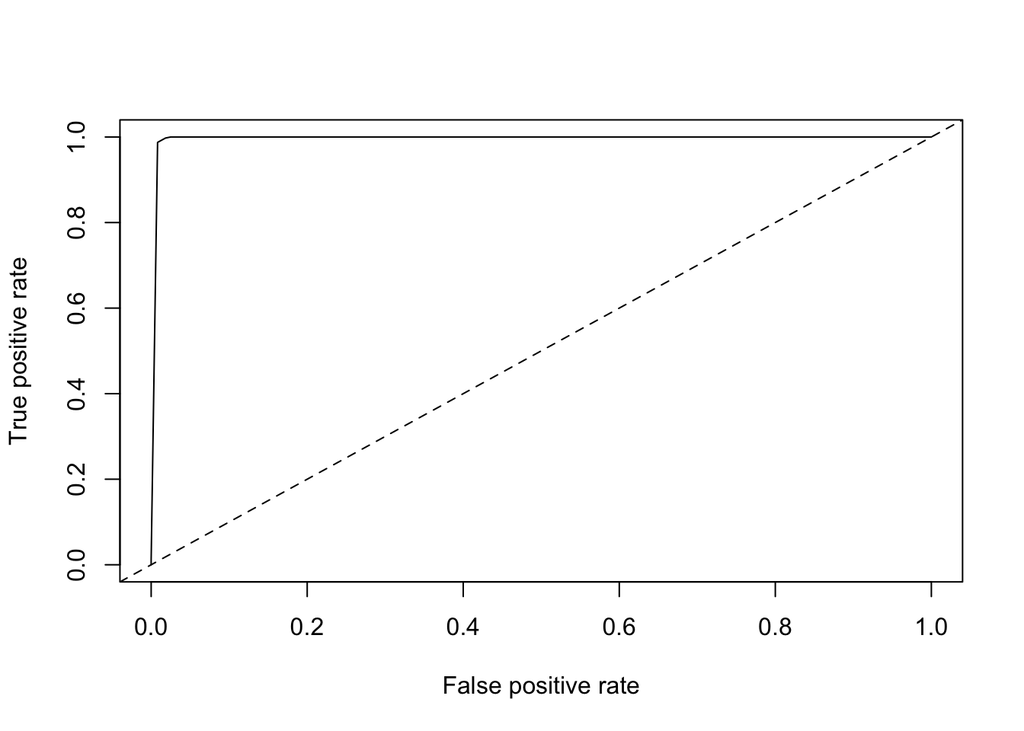

```r
#Plot the curve
pred.detail <- prediction(df$pred, df$level.up)
plot(performance(pred.detail, "tpr", "fpr"))
abline(0, 1, lty = 2)
```

```r
#Calculate the Area Under the Curve
unlist(slot(performance(pred.detail,"auc"), "y.values")) #Unlist liberates the AUC value from the "performance" object created by ROCR
```

```
## [1] 0.99575
```

## 6. Repeat process and build new tree model with unused variables

```r
c.tree1 <- rpart(level.up ~ post.test.score + pre.test.score + av.assignment.score, method="class", data=df, control=rpart.control(minsplit=15, cp=.00001))
printcp(c.tree1)
```

```
##
## Classification tree:
## rpart(formula = level.up ~ post.test.score + pre.test.score +
##     av.assignment.score, data = df, method = "class", control = rpart.control(minsplit = 15,
##     cp = 1e-05))
##
## Variables actually used in tree construction:
## [1] av.assignment.score post.test.score
##
## Root node error: 400/1000 = 0.4
##
## n= 1000
##
##        CP nsplit rel error xerror     xstd
## 1 0.93000      0      1.00   1.00 0.038730
## 2 0.07000      1      0.07   0.07 0.013042
## 3 0.00001      2      0.00   0.00 0.000000
```

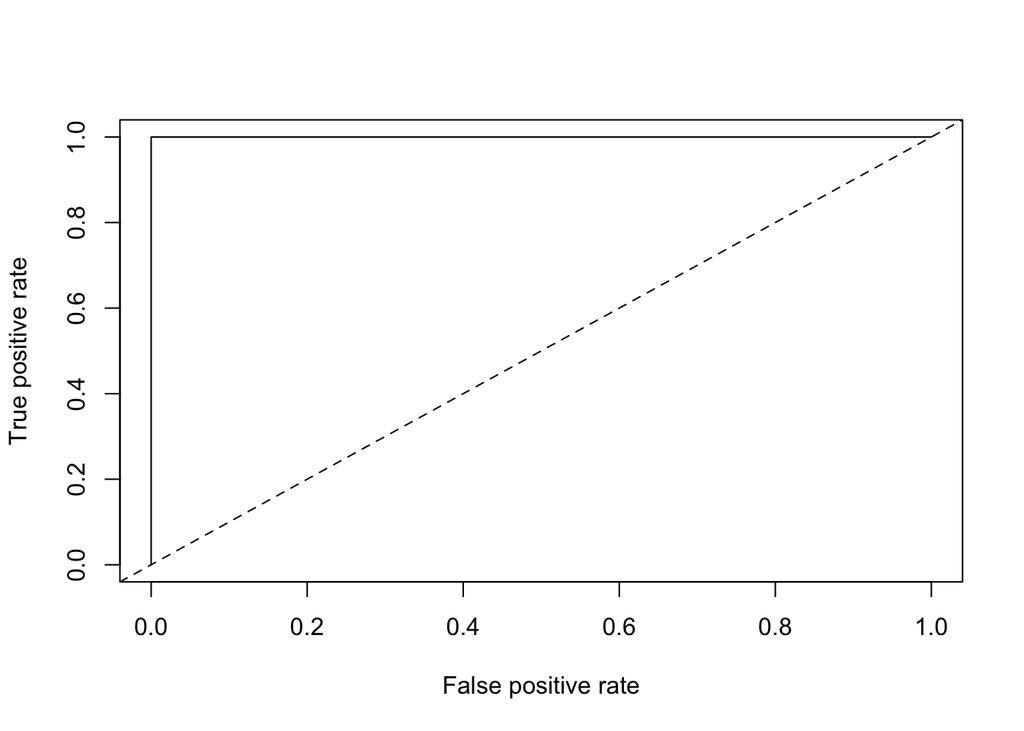

```r
post(c.tree1, file = "tree1.ps", title = "Classification Tree")

df$pred2 <- predict(c.tree1, df, type = "prob")[,2]

pred.detail2 <- prediction(df$pred2, df$level.up)
plot(performance(pred.detail2, "tpr", "fpr"))
abline(0, 1, lty = 2)
```

```r
unlist(slot(performance(pred.detail2,"auc"), "y.values"))
```

```
## [1] 1
```

## 7. Examine Thresholds

Threshold at .8

```r
# Set .8 probability threshold for valid prediction 'yes', else 'no'.
df$threshold.pred1 <- ifelse(df$pred >= .8, 'yes', 'no')

# Generate confusion matrix and model diagnostics:
confusionMatrix(data = df$threshold.pred1, reference = df$level.up)
```

```
## Confusion Matrix and Statistics
##
##           Reference
## Prediction  no yes
##        no  595   5
##        yes   5 395
##
##                Accuracy : 0.99
##                  95% CI : (0.9817, 0.9952)
##     No Information Rate : 0.6
##     P-Value [Acc > NIR] : <2e-16
##
##                   Kappa : 0.9792
##  Mcnemar's Test P-Value : 1
##
##             Sensitivity : 0.9917
##             Specificity : 0.9875
##          Pos Pred Value : 0.9917
##          Neg Pred Value : 0.9875
##              Prevalence : 0.6000
##          Detection Rate : 0.5950
##    Detection Prevalence : 0.6000
##       Balanced Accuracy : 0.9896
##
##        'Positive' Class : no
##
```

# Now choose a different threshold value and repeat these diagnostics. What conclusions can you draw about your two thresholds?

Threshold at .9873418

```r
df$threshold.pred1 <- ifelse(df$pred >= 0.9873418, 'yes', 'no')
confusionMatrix(data = df$threshold.pred1, reference = df$level.up)
```

```
## Confusion Matrix and Statistics
##
##           Reference
## Prediction  no yes
##        no  600 395
##        yes   0   5
##
##                Accuracy : 0.605
##                  95% CI : (0.5739, 0.6355)
##     No Information Rate : 0.6
##     P-Value [Acc > NIR] : 0.3865
##
##                   Kappa : 0.015
##  Mcnemar's Test P-Value : <2e-16
##
##             Sensitivity : 1.0000
##             Specificity : 0.0125
##          Pos Pred Value : 0.6030
##          Neg Pred Value : 1.0000
##              Prevalence : 0.6000
##          Detection Rate : 0.6000
##    Detection Prevalence : 0.9950
##       Balanced Accuracy : 0.5062
##
##        'Positive' Class : no
##
```

The Kappa calculated at the threshold .987418 has a lower Kappa than the threshold at .8. The difference is likely due to the difference in the set thresholds. So the greater the threshold, the lower the Kappa value.

Note: A Cohen’s Kappa of 1 “implies perfect agreement” (http://www.pmean.com/definitions/kappa.htm) between observed and expected agreement.